# Projet de Statistique Prévision : Wikipedia Traffic Forecast

### **Construire le model ARIMA**

On a bien déterminé les valeurs de p,d et q. On a toutes les paramètres nécessaires pour fit le ARIMA

##### **Pour les pages en Anglais (p,d,q) = (2,1,2)**

```python
# 2,1,2 ARIMA Model
model = ARIMA(data_en, order=(2,1,2))
results = model.fit()
```

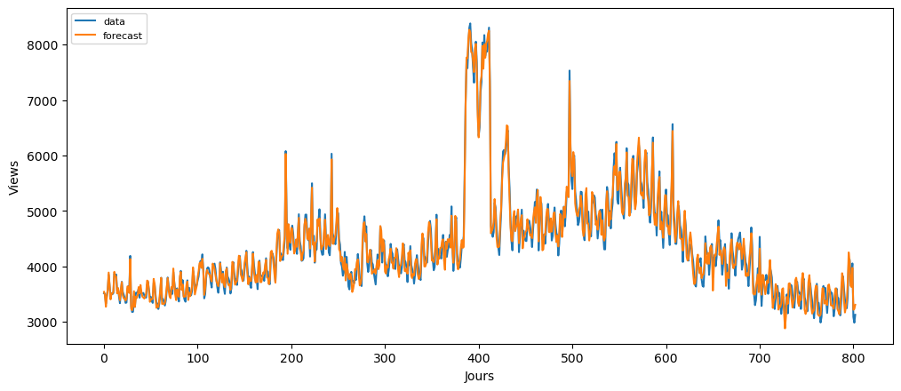

```python
# Forecast
forecast = results.predict(1,803,typ='levels')  # 95% conf

#plot
plt.figure(figsize=(12,5), dpi=100)
plt.plot(np.arange(0,803),data_en, label='data')
plt.plot(np.arange(0,803),forecast.values, label='forecast')
plt.xlabel('Jours')
plt.ylabel('Views')
plt.legend(loc='upper left', fontsize=8)
plt.show()
```

La prévision ajustée et les données réelles peuvent alors paraître artificiellement bonnes.

##### **Pour les pages en Allemagne (p,d,q) = (2,1,2)**

```python
# 1,2,1 ARIMA Model
model = ARIMA(data_de, order=(2,1,2))
results = model.fit()
```

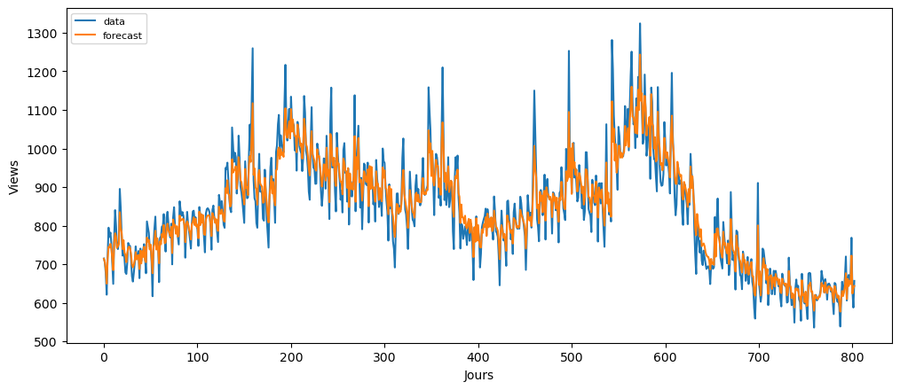

```python
# Forecast
forecast = results.predict(1,803,typ='levels')  # 95% conf

#plot
plt.figure(figsize=(12,5), dpi=100)
plt.plot(np.arange(0,803),data_de, label='data')
plt.plot(np.arange(0,803),forecast.values, label='forecast')
plt.xlabel('Jours')
plt.ylabel('Views')
plt.legend(loc='upper left', fontsize=8)
plt.show()
```

La prévision ajustée et les données réelles peuvent alors paraître artificiellement bonnes.

##### **Pour les pages en Francais (p,d,q) = (2,1,2)**

```python
# 2,1,2 ARIMA Model
model = ARIMA(data_fr, order=(2,1,2))
results = model.fit()
#print(results.summary())
```

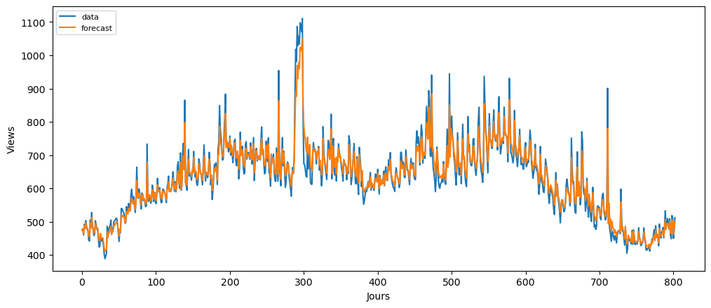

```python
# Forecast
forecast = results.predict(1,803,typ='levels')  # 95% conf

#plot

plt.figure(figsize=(12,5), dpi=100)
plt.plot(np.arange(0,803),data_fr, label='data')
plt.plot(np.arange(0,803),forecast.values, label='forecast')
plt.xlabel('Jours')
plt.ylabel('Views')
plt.legend(loc='upper left', fontsize=8)
plt.show()
```

La prévision ajustée et les données réelles peuvent alors paraître artificiellement bonnes.

##### **Pour les pages en Chinois (p,d,q) = (2,1,2)**

```python
# 2,1,2 ARIMA Model
model = ARIMA(data_ch, order=(2,1,2))
results = model.fit()
#print(results.summary())
```

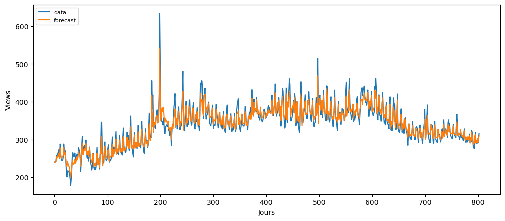

```python
# Forecast
forecast = results.predict(1,803,typ='levels')  # 95% conf

#plot

plt.figure(figsize=(12,5), dpi=100)
plt.plot(np.arange(0,803),data_ch, label='data')
plt.plot(np.arange(0,803),forecast.values, label='forecast')
plt.xlabel('Jours')
plt.ylabel('Views')
plt.legend(loc='upper left', fontsize=8)
plt.show()
```

# **Construire le modèle ARIMA optimal en utilisant Out-of-Time Cross validation**

Dans Out-of-Time Cross validation, on fait quelques pas en arrière dans le temps et prévoit dans le futur autant de pas qu'on a fait en arrière. Ensuite, on compare la prévision avec les données réelles.

##### **Pour les pages en Anglais**

```python
#Split les données de proportions 80:20
train_ind = int(len(data_en)*0.8)
train = data_en[:train_ind] #642 valeurs dans le train
test = data_en[train_ind:] # 161 valeurs dans le test
```

```python
model = ARIMA(train, order=(2, 1, 2))
results= model.fit()
```

```python
# Forecast
fc = results.predict(1,803,typ='levels')
#Intervalle de confidence
forecast_val=results.get_forecast(steps=161,alpha=0.05) #95% confidence
confidence_int = forecast_val.conf_int()

lower_series = confidence_int.iloc[:, 0]
upper_series = confidence_int.iloc[:, 1]
```

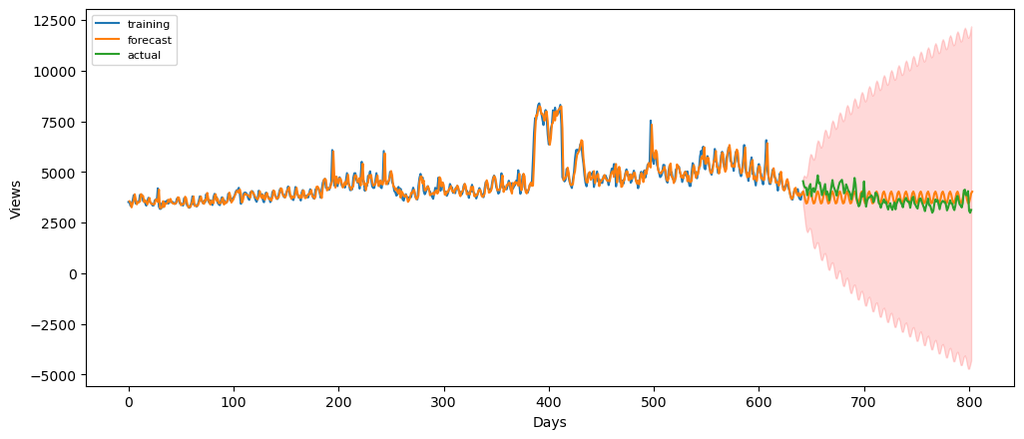

```python
plt.figure(figsize=(12,5), dpi=100)
plt.plot(np.arange(0,642),train, label='training')
plt.plot(np.arange(1,804),fc.values, label='forecast')
plt.plot(np.arange(642,803),test.values, label='actual')
plt.fill_between(np.arange(642,803),
                 lower_series,
                 upper_series,
                 color='r', alpha=.15)
plt.xlabel('Days')
plt.ylabel('Views')
plt.legend(loc='upper left', fontsize=8)
plt.show()
```

```python
#Accuracy metrics
def accuracy_metrics(forecast, actual):
    mape = np.mean(np.abs(forecast - actual)/np.abs(actual))  # MAPE
    mins = np.amin(np.hstack([forecast[:,None],
                              actual[:,None]]), axis=1)
    maxs = np.amax(np.hstack([forecast[:,None],
                              actual[:,None]]), axis=1)
    minmax = 1 - np.mean(mins/maxs)             # minmaxerror
    return({'mape':mape,'minmax':minmax})

accuracy_metrics(fc,data_en.values)
```

```
{'mape': 0.04149801549499804, 'minmax': 0.03957430362702874}
```

le MAPE(Mean Absolute Percentage Error) est d'environ 4.14% implique que le modèle est précis à environ 95.86% dans la prédiction. Le MinMax(Min Max error) est d'environ de 4% qui implique que la precision est à environ de 96% dans cette prediction

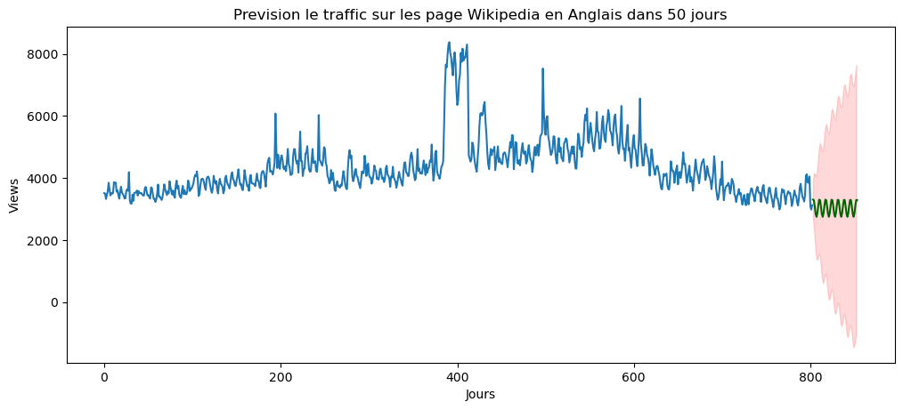

```python
#Forecast pour 50 jours suivants

#models
model = ARIMA(data_en, order=(2, 1, 2))
results= model.fit()

# Forecast
n_periods = 50
fc = results.predict(803,853,typ='levels')  # 95% conf

#Intervalle de confidence
forecast_val=results.get_forecast(steps=n_periods,alpha=0.05)
confidence_int = forecast_val.conf_int()

lower_series = confidence_int.iloc[:, 0]
upper_series = confidence_int.iloc[:, 1]

# Plot
plt.figure(figsize=(12,5), dpi=100)
plt.plot(np.arange(0,803),data_en.values)
plt.plot(np.arange(803,854),fc, color='darkgreen')
plt.fill_between(np.arange(803,853),
                 lower_series,
                 upper_series,
                 color='r', alpha=.15)
plt.xlabel('Jours')
plt.ylabel('Views')
plt.title("Prevision le traffic sur les page Wikipedia en Anglais dans 50 jours")
plt.show()
```

**Conclusion**: On n'est pas très satisfait avec cette prediction. La prediction semble périodique, et c'est évident que le trafic n'est pas de cette forme, ainsi quand on augmente le nombre de jours de prediction, la précision est plus mauvaise par de temps en temps

##### **Pour les pages en Allemagne**

```python
#Split les données de proportions 80:20
train_ind = int(len(data_de)*0.8)
train = data_de[:train_ind] #641 valeurs dans le train
test = data_de[train_ind:] # 161 valeurs dans le test
```

```python
model = ARIMA(train, order=(2, 1, 2))
results= model.fit()
```

```python
# Forecast
fc = results.predict(1,803,typ='levels')
#Intervalle de confidence
forecast_val=results.get_forecast(steps=161,alpha=0.05) #95% confidence
confidence_int = forecast_val.conf_int()

lower_series = confidence_int.iloc[:, 0]
upper_series = confidence_int.iloc[:, 1]
```

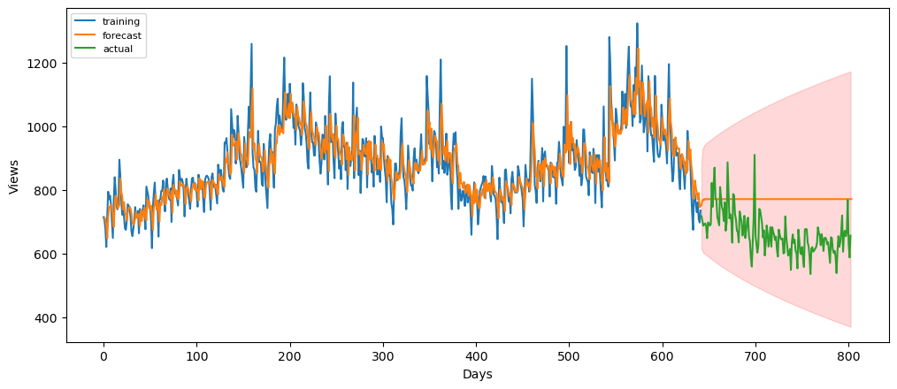

```python
plt.figure(figsize=(12,5), dpi=100)
plt.plot(np.arange(0,642),train, label='training')
plt.plot(np.arange(1,804),fc.values, label='forecast')
plt.plot(np.arange(642,803),test.values, label='actual')
plt.fill_between(np.arange(642,803),
                 lower_series,
                 upper_series,
                 color='r', alpha=.15)
plt.xlabel('Days')
plt.ylabel('Views')
plt.legend(loc='upper left', fontsize=8)
plt.show()
```

```python
#Accuracy metrics
def accuracy_metrics(forecast, actual):
    mape = np.mean(np.abs(forecast - actual)/np.abs(actual))  # MAPE
    mins = np.amin(np.hstack([forecast[:,None],
                              actual[:,None]]), axis=1)
    maxs = np.amax(np.hstack([forecast[:,None],
                              actual[:,None]]), axis=1)
    minmax = 1 - np.mean(mins/maxs)             # minmaxerror
    return({'mape':mape,'minmax':minmax})

accuracy_metrics(fc,data_de.values)
```

```
{'mape': 0.06030298097560872, 'minmax': 0.05329951894114826}
```

On trouve que le MAPE(Mean Average Percentage Error) est environ de 6%, lorsque le minmax(Min Max Error) est environ de 5.3%. Cela signifie que notre modèle est précis à environ 94% par rapport à MAPE et 94.7% par rapport de Min Max Error dans la prédiction.

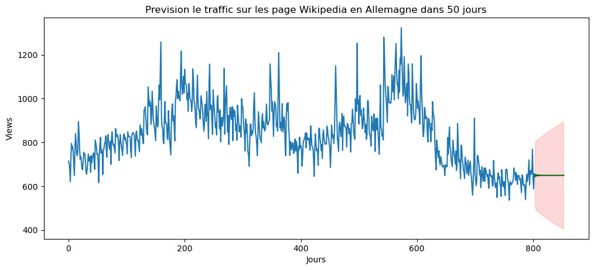

```python
#Forecast pour 50 jours suivants

#models
model = ARIMA(data_de, order=(2, 1, 2))
results= model.fit()

# Forecast
n_periods = 50
fc = results.predict(803,853,typ='levels')  # 95% conf

#Intervalle de confidence
forecast_val=results.get_forecast(steps=n_periods,alpha=0.05)
confidence_int = forecast_val.conf_int()

lower_series = confidence_int.iloc[:, 0]
upper_series = confidence_int.iloc[:, 1]

# Plot
plt.figure(figsize=(12,5), dpi=100)
plt.plot(np.arange(0,803),data_de.values)
plt.plot(np.arange(803,854),fc, color='darkgreen')
plt.fill_between(np.arange(803,853),
                 lower_series,
                 upper_series,
                 color='r', alpha=.15)
plt.xlabel('Jours')
plt.ylabel('Views')
plt.title("Prevision le traffic sur les page Wikipedia en Allemagne dans 50 jours")
plt.show()
```

**Conclusion**: On n'est pas satisfaits de notre prédiction. Cette prédiction semble linéaire, cela ne correspond pas au traffic observé en réalité.

##### **Pour les pages en Francais**

```python
#Split les données de proportions 80:20
train_ind = int(len(data_fr)*0.8)
train = data_fr[:train_ind] #641 valeurs dans le train
test = data_fr[train_ind:] # 161 valeurs dans le test
```

```python
model = ARIMA(train, order=(2, 1, 2))
results= model.fit()
```

```python
# Forecast
fc = results.predict(1,803,typ='levels')
#Intervalle de confidence
forecast_val=results.get_forecast(steps=161,alpha=0.05) #95% confidence
confidence_int = forecast_val.conf_int()

lower_series = confidence_int.iloc[:, 0]
upper_series = confidence_int.iloc[:, 1]
```

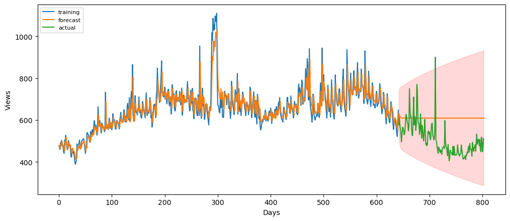

```python
plt.figure(figsize=(12,5), dpi=100)
plt.plot(np.arange(0,642),train, label='training')
plt.plot(np.arange(1,804),fc.values, label='forecast')
plt.plot(np.arange(642,803),test.values, label='actual')
plt.fill_between(np.arange(642,803),
                 lower_series,
                 upper_series,
                 color='r', alpha=.15)
plt.xlabel('Days')
plt.ylabel('Views')
plt.legend(loc='upper left', fontsize=8)
plt.show()
```

```python
#Accuracy metrics
def accuracy_metrics(forecast, actual):
    mape = np.mean(np.abs(forecast - actual)/np.abs(actual))#MAPE
    mins = np.amin(np.hstack([forecast[:,None],
                              actual[:,None]]), axis=1)
    maxs = np.amax(np.hstack([forecast[:,None],
                              actual[:,None]]), axis=1)
    minmax = 1 - np.mean(mins/maxs) #minmaxerror
    return({'mape':mape,'minmax':minmax})

accuracy_metrics(fc,data_fr.values)
```

```
{'mape': 0.0648559431074301, 'minmax': 0.05381242234208283}
```

On trouve que le MAPE(Mean Average Percentage Errror) est environ de 6.5%, lors que le minmax(Min Max error) est environ de 5.4%. Cela signifie que notre modèle est précis à environ 93.5% par rapport à MAPE et 94.6% par rapport de Min Max Error dans la prédiction.

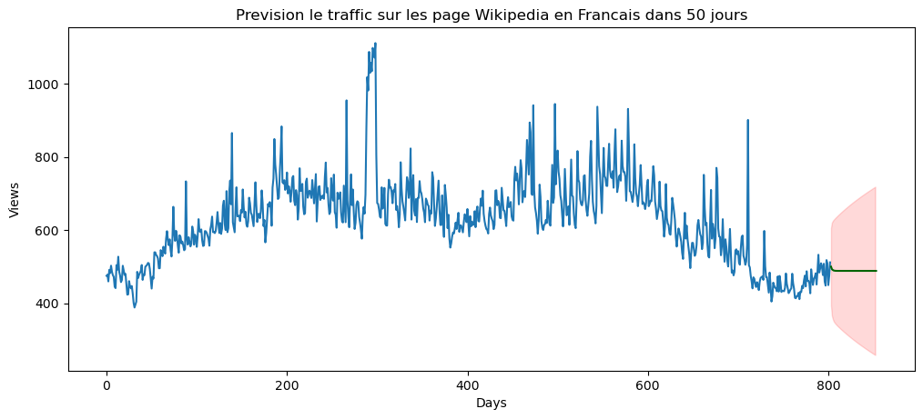

```python
#Forecast pour 50 jours suivants

#models
model = ARIMA(data_fr, order=(2, 1,2))
results= model.fit()

# Forecast
n_periods = 50
fc = results.predict(803,853,typ='levels')  # 95% conf

#Intervalle de confidence
forecast_val=results.get_forecast(steps=n_periods,alpha=0.05)
confidence_int = forecast_val.conf_int()

lower_series = confidence_int.iloc[:, 0]
upper_series = confidence_int.iloc[:, 1]

# Plot
plt.figure(figsize=(12,5), dpi=100)
plt.plot(np.arange(0,803),data_fr.values)
plt.plot(np.arange(803,854),fc,color='darkgreen')
plt.fill_between(np.arange(803,853),
                 lower_series,
                 upper_series,
                 color='r', alpha=.15)
plt.xlabel('Days')
plt.ylabel('Views')
plt.title("Prevision le traffic sur les page Wikipedia en Francais dans 50 jours")
plt.show()
```

**Conclusion**: On n'est pas tres satisfait avec notre prédiction. Pareil avec les données pour les pages en Allemagne, cette prédiction semble linéaire, celle la est impossible avec le trafic en réalité

##### **Pour les pages en Chinois**

```python
#Split les données de proportions 80:20
train_ind = int(len(data_ch)*0.8)
train = data_ch[:train_ind] #641 valeurs dans le train
test = data_ch[train_ind:] # 161 valeurs dans le test
```

```python
model = ARIMA(train, order=(2, 1, 2))
results= model.fit()
```

```python
# Forecast
fc = results.predict(1,803,typ='levels')
#Intervalle de confidence
forecast_val=results.get_forecast(steps=161,alpha=0.05) #95% confidence
confidence_int = forecast_val.conf_int()

lower_series = confidence_int.iloc[:, 0]
upper_series = confidence_int.iloc[:, 1]
```

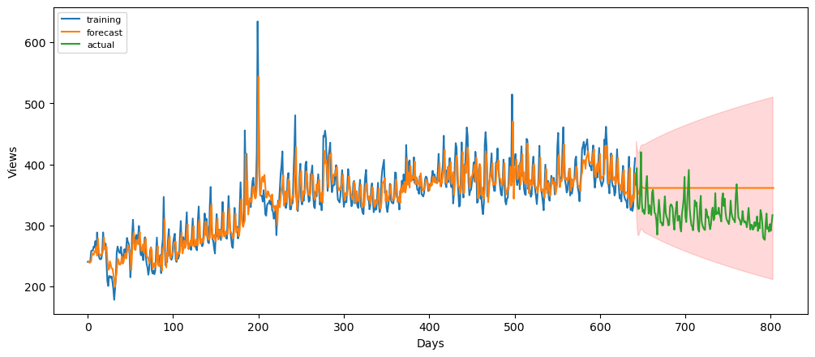

```python
plt.figure(figsize=(12,5), dpi=100)
plt.plot(np.arange(0,642),train, label='training')
plt.plot(np.arange(1,804),fc.values, label='forecast')
plt.plot(np.arange(642,803),test.values, label='actual')
plt.fill_between(np.arange(642,803),
                 lower_series,
                 upper_series,
                 color='r', alpha=.15)
plt.xlabel('Days')
plt.ylabel('Views')
plt.legend(loc='upper left', fontsize=8)
plt.show()
```

```python
#Accuracy metrics
def accuracy_metrics(forecast, actual):
    mape = np.mean(np.abs(forecast - actual)/np.abs(actual))  # MAPE
    mins = np.amin(np.hstack([forecast[:,None],
                              actual[:,None]]), axis=1)
    maxs = np.amax(np.hstack([forecast[:,None],
                              actual[:,None]]), axis=1)
    minmax = 1 - np.mean(mins/maxs)             # minmax
    return({'mape':mape, 'minmax':minmax})

accuracy_metrics(fc,data_ch.values)
```

```
{'mape': 0.054614075437687516, 'minmax': 0.049827832184477616}
```

On trouve que le MAPE(Mean Average Percentage Errror) est environ de 5.5%, lors que le minmax(Min Max error) est environ de 5%. Cela signifie que notre modèle est précis à environ 94.5% par rapport à MAPE et 95% par rapport de Min Max Error dans la prédiction.

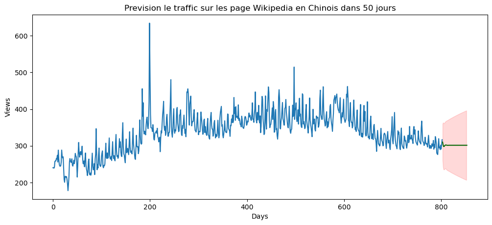

```python
#Forecast pour 50 jours suivants

#models
model = ARIMA(data_ch, order=(2, 1,2))
results= model.fit()

# Forecast
n_periods = 50
fc = results.predict(803,853,typ='levels')  # 95% conf

#Intervalle de confidence
forecast_val=results.get_forecast(steps=n_periods,alpha=0.05)
confidence_int = forecast_val.conf_int()

lower_series = confidence_int.iloc[:, 0]
upper_series = confidence_int.iloc[:, 1]

# Plot
plt.figure(figsize=(12,5), dpi=100)
plt.plot(np.arange(0,803),data_ch.values)
plt.plot(np.arange(803,854),fc,color='darkgreen')
plt.fill_between(np.arange(803,853),
                 lower_series,
                 upper_series,
                 color='r', alpha=.15)
plt.xlabel('Days')
plt.ylabel('Views')
plt.title("Prevision le traffic sur les page Wikipedia en Chinois dans 50 jours")
plt.show()
```

**Conclusion**: On n'est pas tres satisfait avec notre prédiction. Pareil avec les données pour les autres pages, cette prédiction semble linéaire, celle la est impossible avec le trafic en réalité

### Conclusion générale sur l'ARIMA

On n'est pas satisfaits de notre prédiction.

Il existe plusieurs raisons pour lesquelles un modèle ARIMA peut ne pas fonctionner aussi bien que prévu :

- Malgré nos transformations, la série peut ne pas être stationnaire. Si c'est le cas, le modèle peut ne pas bien s'adapter aux données.
- Le modèle spécifié, i.e. les paramètres p,d et q ne sont peut tre pas les bons pour les données. Un mauvais choix peut faire que le modèle ne s'adapte pas bien aux données.
- Il peut y avoir des valeurs aberrantes ou d'autres observations inhabituelles dans les données. Les valeurs aberrantes ou d'autres observations inhabituelles peuvent avoir un impact important sur le modèle, en particulier si la taille de l'échantillon est petite.
- Il peut y avoir des valeurs manquantes ou d'autres problèmes avec les données.
- Le modèle est peut-être trop simple pour les données. Un modèle ARIMA est un modèle linéaire, il peut donc ne pas être en mesure de capturer les relations non linéaires dans les données. Si les données ont des modèles non linéaires, le modèle peut ne pas bien s'adapter aux données.

### À suivre...

Nous poursuivons nos prédictions cette fois-ci en utilisant d'autres méthodes de prédictions, et notamment celles vues en cours : Ridge regression, Lasso regression, XGBoost et Random Forest.

# Prédiction avec Ridge regression

### Sur les articles en Anglais

```python
# Convert index to datetime object
data_en.index = pd.to_datetime(data_en.index)

# Split the data into training and test sets
train_size = int(len(data_en) * 0.8)
train_data = data_en.iloc[:train_size]
test_data = data_en.iloc[train_size:]


# Convert the datetime index to a float value
start_date = train_data.index.min()
train_data['days_since_start'] = (train_data.index - start_date).days
test_data['days_since_start'] = (test_data.index - start_date).days
```

```python
# Define the Ridge Regression model with cross-validation
alphas = [0.1, 1.0, 10.0]
ridge_cv = RidgeCV(alphas=alphas, cv=5)

# Train the model on the training data
X_train = train_data['days_since_start'].values.reshape(-1, 1)
y_train = train_data.values.reshape(-1, 1)
y_train = np.delete(y_train, -1, axis=0)
ridge_cv.fit(X_train, y_train)

# Print the best alpha value
print(f"Best alpha: {ridge_cv.alpha_}")

# Make predictions on the test data using the best alpha value
X_test = test_data['days_since_start'].values.reshape(-1, 1)
y_test = test_data.values.reshape(-1, 1)
y_test = np.delete(y_test, -1, axis=0)
y_pred = ridge_cv.predict(X_test)

# Evaluate the performance of the model
mse = mean_squared_error(y_test, y_pred)
rmse = np.sqrt(mse)
mae = mean_absolute_error(y_test, y_pred)
r2 = r2_score(y_test, y_pred)


# Print the evaluation metrics
print(f"Ridge Regression - MSE: {mse:.2f}, RMSE: {rmse:.2f}, MAE: {mae:.2f}, R2 score: {r2:.2f}")
```

```
Best alpha: 0.1
Ridge Regression - MSE: 4081594.40, RMSE: 2020.30, MAE: 1952.68, R2 score: -22.54
```

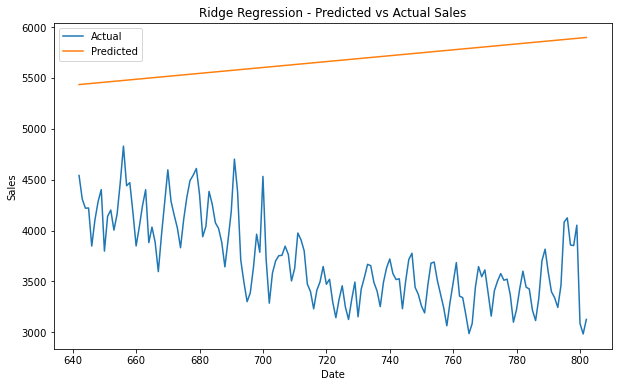

```python
# Plot the predicted values and the actual values
plt.figure(figsize=(10, 6))
plt.plot(X_test, y_test, label='Actual')
plt.plot(X_test, y_pred, label='Predicted')
plt.legend()
plt.xlabel('Date')
plt.ylabel('Sales')
plt.title('Ridge Regression - Predicted vs Actual Sales')
plt.show()
```

# Prediction avec Lasso Regression

```python
# Convert index to datetime object
data_en.index = pd.to_datetime(data_en.index)

# Split the data into training and test sets
train_size = int(len(data_en) * 0.8)
train_data = data_en.iloc[:train_size]
test_data = data_en.iloc[train_size:]


# Convert the datetime index to a float value
start_date = train_data.index.min()
train_data['days_since_start'] = (train_data.index - start_date).days
test_data['days_since_start'] = (test_data.index - start_date).days
```

```python
# Define the Ridge Regression model with cross-validation
alphas = [0.1, 1.0, 10.0]
lasso_cv = LassoCV(alphas=alphas, cv=5)

# Train the model on the training data
X_train = train_data['days_since_start'].values.reshape(-1, 1)
y_train = train_data.values.reshape(-1, 1)
y_train = np.delete(y_train, -1, axis=0)
lasso_cv.fit(X_train, y_train)

# Print the best alpha value
print(f"Best alpha: {lasso_cv.alpha_}")

# Make predictions on the test data using the best alpha value
X_test = test_data['days_since_start'].values.reshape(-1, 1)
y_test = test_data.values.reshape(-1, 1)
y_test = np.delete(y_test, -1, axis=0)
y_pred = lasso_cv.predict(X_test)

# Evaluate the performance of the model
mse = mean_squared_error(y_test, y_pred)
rmse = np.sqrt(mse)
mae = mean_absolute_error(y_test, y_pred)
r2 = r2_score(y_test, y_pred)

# Print the evaluation metrics
print(f"Ridge Regression - MSE: {mse:.2f}, RMSE: {rmse:.2f}, MAE: {mae:.2f}, R2 score: {r2:.2f}")
```

```
Best alpha: 10.0
Ridge Regression - MSE: 4081126.51, RMSE: 2020.18, MAE: 1952.57, R2 score: -22.54
```

# Prédiction avec XGBoost

### Sur les articles en Anglais

#### Rappel : vues des articles wikipédia en anglais en moyenne

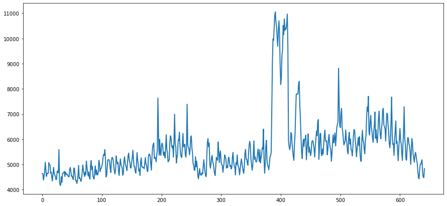

```python
train_ind = int(len(data_en)*0.8)
train = data_en[:train_ind] #641 valeurs dans le train
test = data_en[train_ind:]

train = train.to_frame()
train.columns = ['y']

plt.figure(figsize=(15, 7))
plt.plot(train.y.values, label="actual", linewidth=2.0);
```

```python
# Ajout d'un d'1 à 7 pas en arrière
for i in range(1, 8):
    train["lag_{}".format(i)] = train.y.shift(i)
train.tail()
```

|  | y | lag_1 | lag_2 | lag_3 | lag_4 | lag_5 | lag_6 | lag_7 |
| --- | --- | --- | --- | --- | --- | --- | --- | --- |
| 2017-03-29 | 5182.510791 | 5109.558393 | 5005.346283 | 5006.523321 | 4767.011331 | 4426.551259 | 4484.150420 | 4717.031175 |
| 2017-03-30 | 4651.347062 | 5182.510791 | 5109.558393 | 5005.346283 | 5006.523321 | 4767.011331 | 4426.551259 | 4484.150420 |
| 2017-03-31 | 4499.341847 | 4651.347062 | 5182.510791 | 5109.558393 | 5005.346283 | 5006.523321 | 4767.011331 | 4426.551259 |
| 2017-04-01 | 4472.170324 | 4499.341847 | 4651.347062 | 5182.510791 | 5109.558393 | 5005.346283 | 5006.523321 | 4767.011331 |
| 2017-04-02 | 4831.191367 | 4472.170324 | 4499.341847 | 4651.347062 | 5182.510791 | 5109.558393 | 5005.346283 | 5006.523321 |

```python
tscv = TimeSeriesSplit(n_splits=3)
```

```python
def timeseries_train_test_split(X, y, test_size):

    test_index = int(len(X)*(1-test_size))

    X_train = X.iloc[:test_index]
    y_train = y.iloc[:test_index]
    X_test = X.iloc[test_index:]
    y_test = y.iloc[test_index:]

    return X_train, X_test, y_train, y_test

y = train.dropna().y
X = train.dropna().drop(['y'], axis=1)
```

```python
# On garde 20% des données pour l'ensemble test
# donc l'ensemble Test est de ~127 jours
X_train, X_test, y_train, y_test = timeseries_train_test_split(X, y, test_size=0.20)


print(X_train.shape, y_train.shape, X_test.shape, y_test.shape)
```

```
(508, 7) (508,) (127, 7) (127,)
```

### Ajout de features : jour de la semaine et week-end

```python
train.index = pd.to_datetime(train.index)
train["Jour de la semaine"] = train.index.weekday
train['Weekend'] = train.index.weekday.isin([5,6])*1
train.tail(7)
```

|  | y | lag_1 | lag_2 | lag_3 | lag_4 | lag_5 | lag_6 | lag_7 | Jour de la semaine | Weekend |
| --- | --- | --- | --- | --- | --- | --- | --- | --- | --- | --- |
| 2017-03-27 | 5005.346283 | 5006.523321 | 4767.011331 | 4426.551259 | 4484.150420 | 4717.031175 | 5041.409233 | 5176.765588 | 0 | 0 |
| 2017-03-28 | 5109.558393 | 5005.346283 | 5006.523321 | 4767.011331 | 4426.551259 | 4484.150420 | 4717.031175 | 5041.409233 | 1 | 0 |
| 2017-03-29 | 5182.510791 | 5109.558393 | 5005.346283 | 5006.523321 | 4767.011331 | 4426.551259 | 4484.150420 | 4717.031175 | 2 | 0 |
| 2017-03-30 | 4651.347062 | 5182.510791 | 5109.558393 | 5005.346283 | 5006.523321 | 4767.011331 | 4426.551259 | 4484.150420 | 3 | 0 |
| 2017-03-31 | 4499.341847 | 4651.347062 | 5182.510791 | 5109.558393 | 5005.346283 | 5006.523321 | 4767.011331 | 4426.551259 | 4 | 0 |
| 2017-04-01 | 4472.170324 | 4499.341847 | 4651.347062 | 5182.510791 | 5109.558393 | 5005.346283 | 5006.523321 | 4767.011331 | 5 | 1 |
| 2017-04-02 | 4831.191367 | 4472.170324 | 4499.341847 | 4651.347062 | 5182.510791 | 5109.558393 | 5005.346283 | 5006.523321 | 6 | 1 |

### Mise à l'échelle (Scaling)

L'ajout des ces paramètres (Jour de la semaine et weekeend) créée différentes échelles. On ajuste les échelles.

```python
scaler = StandardScaler()

X_train_scaled = scaler.fit_transform(X_train)
X_test_scaled = scaler.transform(X_test)
```

```python
def plotModelResults(model, X_train=X_train, X_test=X_test, plot_intervals=False, plot_anomalies=False):

    prediction = model.predict(X_test)

    plt.figure(figsize=(15, 7))
    plt.plot(prediction, "g", label="prediction", linewidth=2.0)
    plt.plot(y_test.values, label="actual", linewidth=2.0)

    if plot_intervals:
        cv = cross_val_score(model, X_train, y_train,
                                    cv=tscv,
                                    scoring="neg_mean_absolute_error")
        mae = cv.mean() * (-1)
        deviation = cv.std()

        scale = 1.96
        lower = prediction - (mae + scale * deviation)
        upper = prediction + (mae + scale * deviation)

        plt.plot(lower, "r--", label="upper bond / lower bond", alpha=0.5)
        plt.plot(upper, "r--", alpha=0.5)

        if plot_anomalies:
            anomalies = np.array([np.NaN]*len(y_test))
            anomalies[y_test<lower] = y_test[y_test<lower]
            anomalies[y_test>upper] = y_test[y_test>upper]
            plt.plot(anomalies, "o", markersize=10, label = "Anomalies")

    mape_error = mean_absolute_percentage_error(prediction, y_test)
    smape_error = smape(prediction, y_test)
    plt.title("MAPE: "+str(mape_error)+"\n"+"SMAPE: "+str(smape_error))
    plt.legend(loc="best")
    plt.tight_layout()
    plt.grid(True);
```

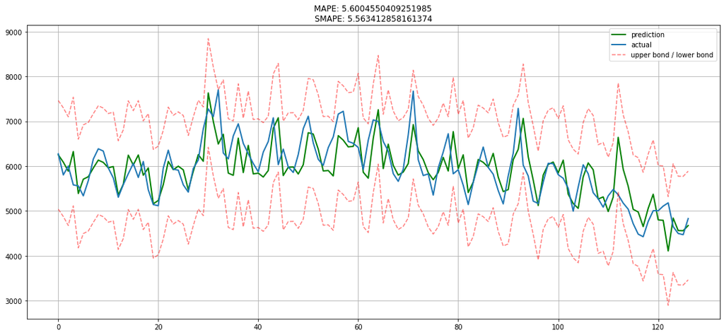

```python
# Fonction pour l'erreur MAPE
def mean_absolute_percentage_error(y_true, y_pred):
    return np.mean(np.abs((y_true - y_pred) / y_true)) * 100

# Fonction pour l'erreur SMAPE
def smape(y_true, y_pred):
    denominator = (np.abs(y_true) + np.abs(y_pred))
    diff = np.abs(y_true - y_pred) / denominator
    diff[denominator == 0] = 0.0
    return 200 * np.mean(diff)


from xgboost import XGBRegressor

xgb = XGBRegressor()
xgb.fit(X_train_scaled, y_train)

plotModelResults(xgb, X_train=X_train_scaled, X_test=X_test_scaled, plot_intervals=True)
```

**Commentaire:** Pour le XGBoost, on trouve que le MAPE est de 5.6%, son score de précision est donc environ de 94.4%

# Prediction avec Random Forest

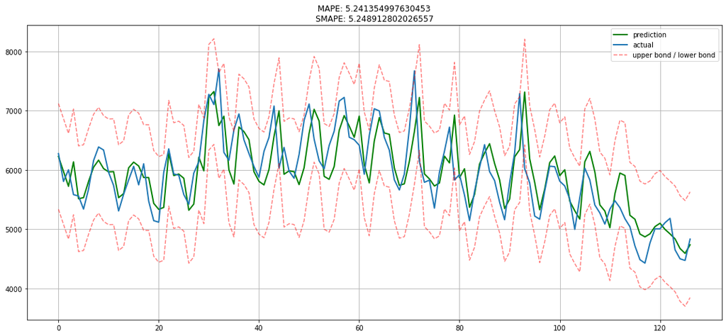

```python
# On définit un modèle pour 1000 arbres
rf = RandomForestRegressor(n_estimators = 1000, random_state = 42)

rf.fit(X_train_scaled, y_train);


plotModelResults(rf, X_train=X_train_scaled, X_test=X_test_scaled, plot_intervals=True)
```

**Commentaire:** Pour le Random Forest, on trouve que le MAPE est de 5.24%, son score de précision est donc environ de 94.76%

# CONCLUSION

Il y a quelques raisons possibles pour les mauvaises performances du modèle ARIMA. Une première possibilité est que les données ne soient pas stationnaires, ce qui signifie que la moyenne, la variance et l'autocovariance ont changé au fil du temps. Une autre possibilité pourrait être que le choix des paramètres p, d et q n'était pas le bon, ou qu'il y avait des valeurs aberrantes ou d'autres observations inhabituelles dans les données auxquelles le modèle n'était pas robuste. Enfin, il est également possible que le modèle soit trop simple pour le type de problème qu'il souhaite résoudre et soit fondamentalement incapable de saisir les relations non-linéaires dans les données.